# Multivariate Data

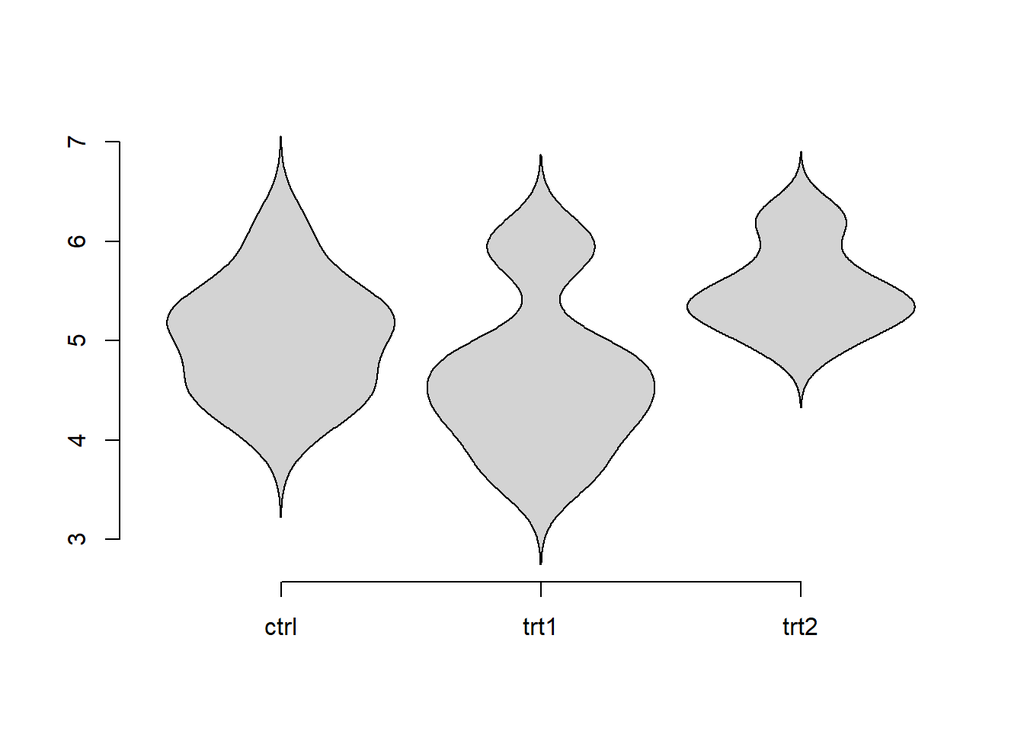

```r
> simple.violinplot(PlantGrowth$weight ~ PlantGrowth$group, col = "lightgray")
```

or with densities using the `simple.densityplot` function from `UsingR` package

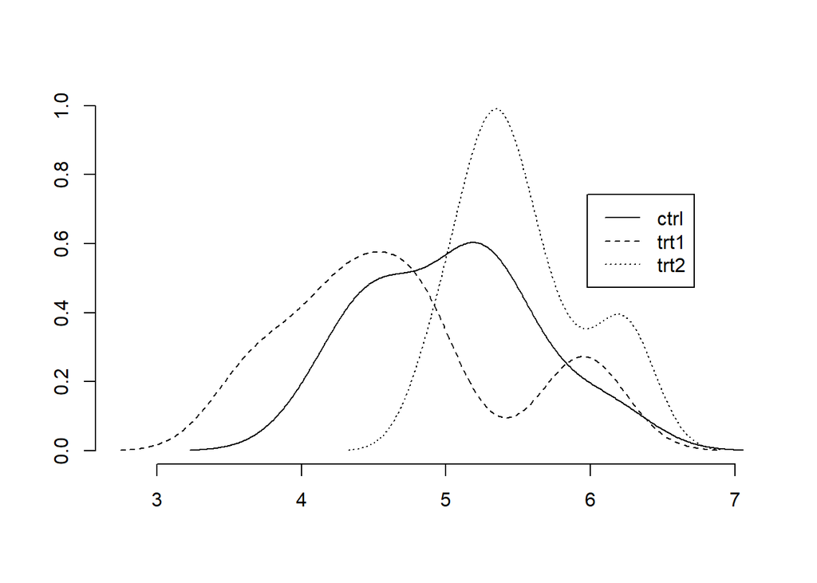

```r
> simple.densityplot(PlantGrowth$weight ~ PlantGrowth$group)
```

Another example. Let`s review the `InsectSprays` data frame presenting the counts of insects in agricultural experiment units treated with different insecticides.

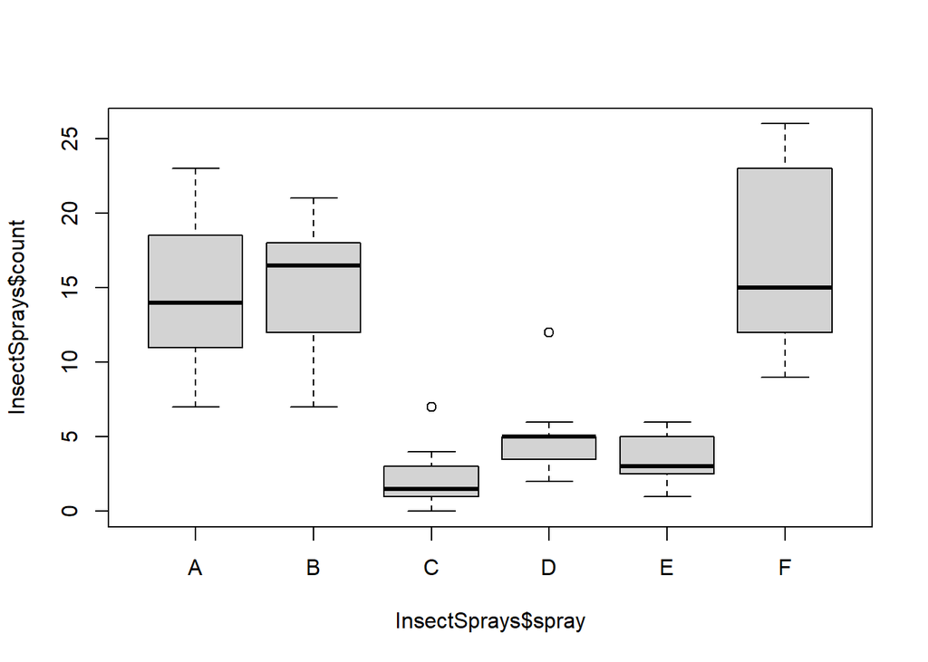

```r
> head(InsectSprays)
  count spray
1    10     A
2     7     A
3    20     A
4    14     A
5    14     A
6    12     A
> boxplot(InsectSprays$count ~ InsectSprays$spray)
```

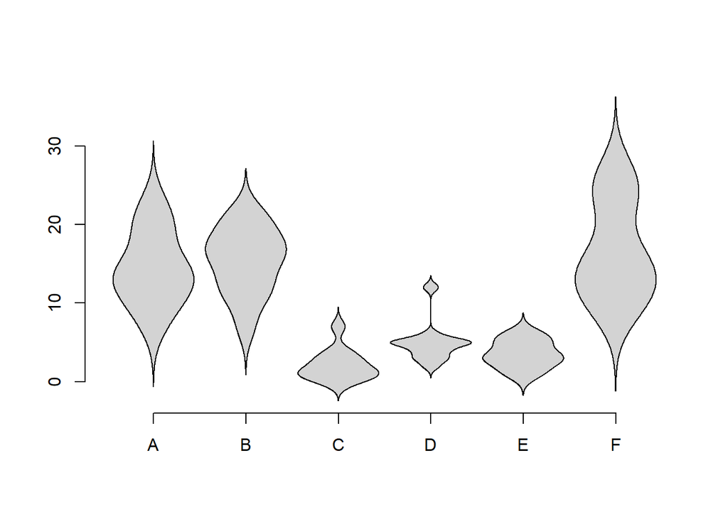

```r
> simple.violinplot(InsectSprays$count ~ InsectSprays$spray, col = "lightgray")
```

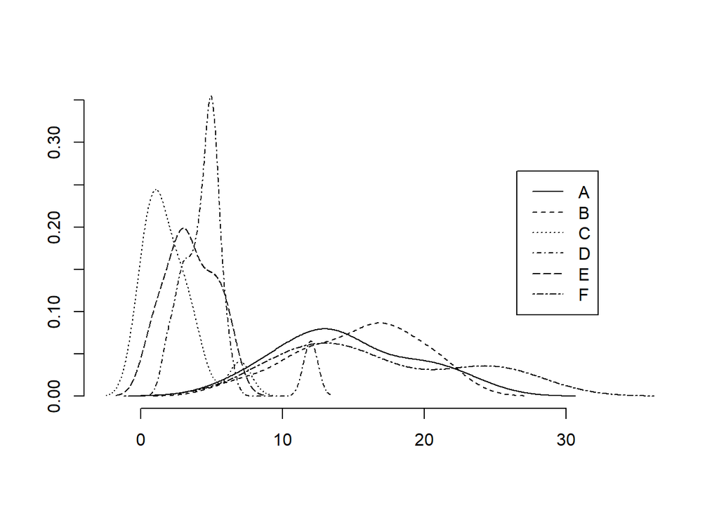

```r
> simple.densityplot(InsectSprays$count ~ InsectSprays$spray)
```

One more example with `ToothGrowth` data frame presenting the effect of vitamin C on tooth growth in guinea pigs. Here we have 1 numerical and 2 categorical variables.

```r
> head(ToothGrowth)
   len supp dose
1  4.2   VC  0.5
2 11.5   VC  0.5
3  7.3   VC  0.5
4  5.8   VC  0.5
5  6.4   VC  0.5
6 10.0   VC  0.5
```

We can use `stripchart` to show the effect of each of the categorical variables.

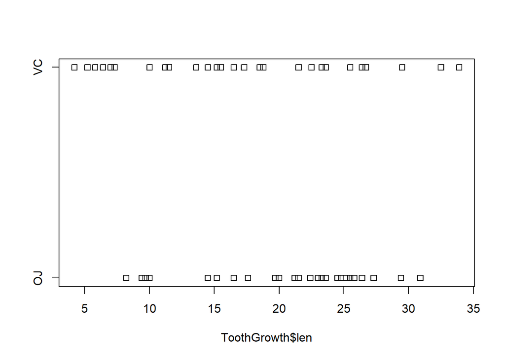

```r
> stripchart(ToothGrowth$len ~ ToothGrowth$supp)
```

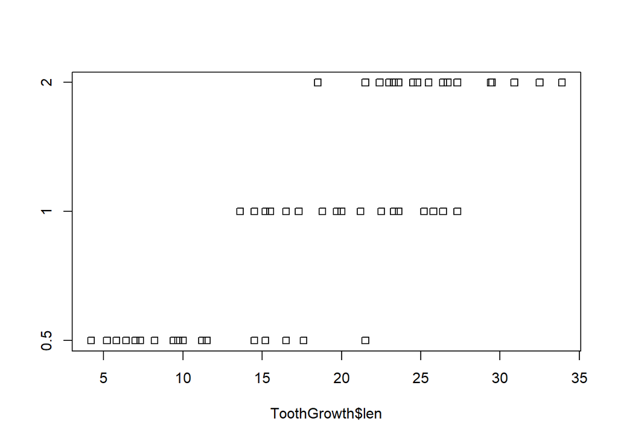

```r
> stripchart(ToothGrowth$len ~ ToothGrowth$dose)
```

But how can we show the effect of both categorical variables on one graph?

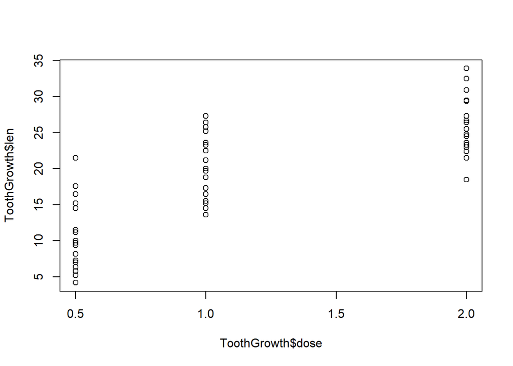

```r
> plot(ToothGrowth$len ~ ToothGrowth$dose)
```

We can plot the other categorical variable on the above plot using different signs or colors marking the observations.

We can use the `pch` and `col` parameters in `plot` function to specify the point symbols and colors.

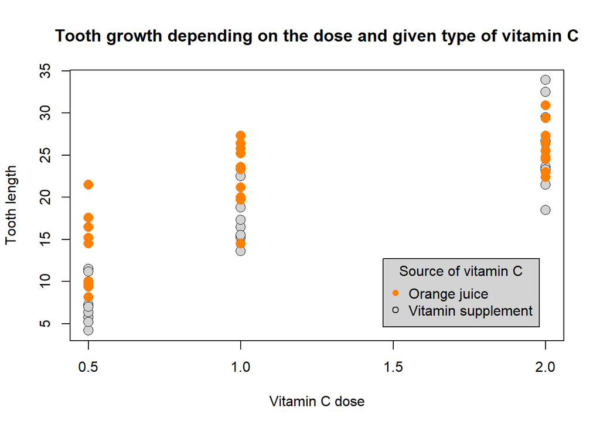

```r
> colors <- c("darkorange1", "black")
> shapes <- c(16, 21)
> plot(ToothGrowth$len ~ ToothGrowth$dose,
+      main = "Tooth growth depending on the dose and given type of vitamin C",
+      xlab = "Vitamin C dose",
+      ylab = "Tooth length",
+      col = colors[ToothGrowth$supp],
+      bg = "lightgray",
+      pch = shapes[ToothGrowth$supp],
+      lwd = 0.9,
+      cex = 1.5)
> legend("bottomright", inset = 0.05,
+        title="Source of vitamin C",
+        legend = c("Orange juice", "Vitamin supplement"),
+        col = colors,
+        bg = "lightgray",
+        pch = shapes)
```

We see that in the groups taking 0.5 mg and 1.0 mg doses, the orange juice source was more effective on the tooth growth.

`lattice` is another useful package for easily displaing multivariate graphics.

```r
> install.packages("lattice")
> ? lattice
```

```r
> library(lattice)
```

Continuing the `Cars93` example we can make a histogram for the `Price` depending on the `Type` of the car

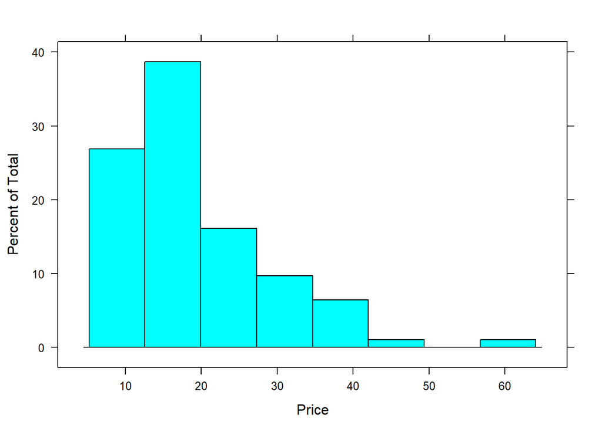

```r
> histogram( ~ Price, data = Cars93)
```

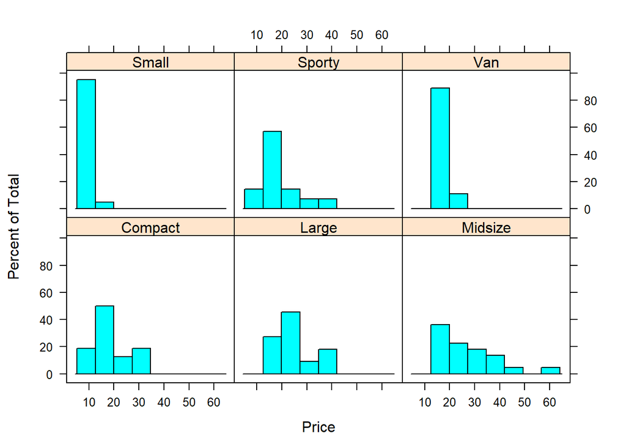

```r
> histogram( ~ Price | Type, data = Cars93)
```